# Supplement

2025-12-22

This page is a supplement to the manuscript, entitled

**A two-stage g-computation framework for health-impact assessment using spatially varying effects**

It contains univariate and bivariate distributions of measures used in the analysis.

# 1 Univariate distributions

## 1.1 Rate-difference outcomes

These RDs represent the estimated number of hospitalizations attributable to each climate-related exposure per 100,000 population per event. A positive rate difference indicates that the climate hazard (heat or wildfire) is causing hospitalizations, and a negative value implies the hazard prevents them. Heat events are defined as two consecutive days, so estimates represent the per-heat-event burden rather than a per-day measures.

### 1.1.1 Heat-related hospitalizations

Histogram of Rate difference per 100,000 person-events over ZCTAs.

| Median | Mean | Percentile_25th | Percentile_75th |
| --- | --- | --- | --- |
| -0.668 | NA | -2.616 | 0.829 |

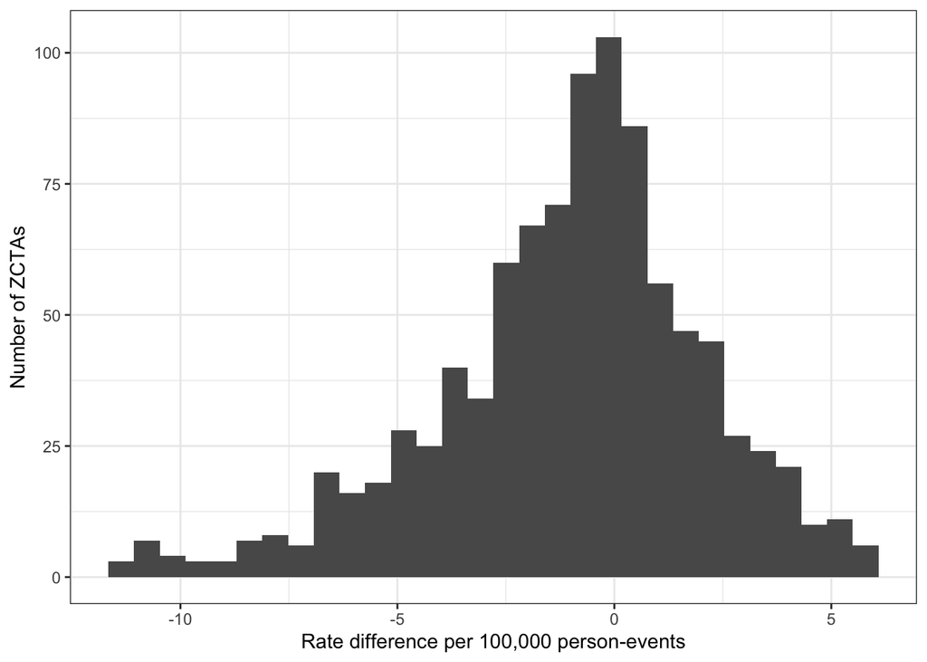

### 1.1.2 Wildfire-related hospitalizations

Histogram of Rate difference per 100,000 person-events over ZCTAs.

| Median | Mean | Percentile_25th | Percentile_75th |
| --- | --- | --- | --- |
| -0.059 | 0.086 | -0.726 | 0.676 |

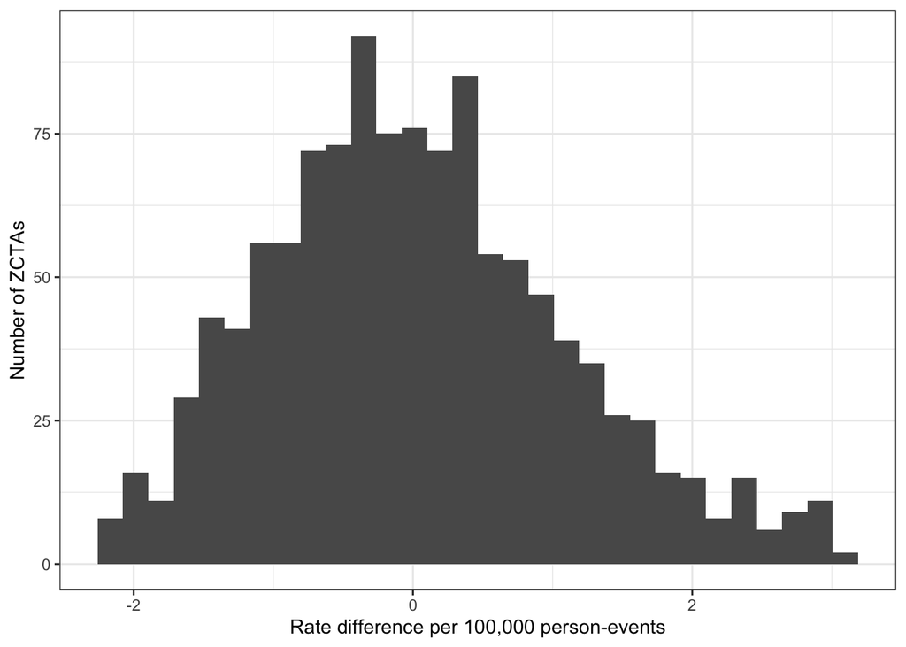

## 1.2 Intervention measures

The intervention measures are: * Impervious surfaces * Tree canopy

Below are histograms of these measures over ZCTAs.

### 1.2.1 Impervious surfaces

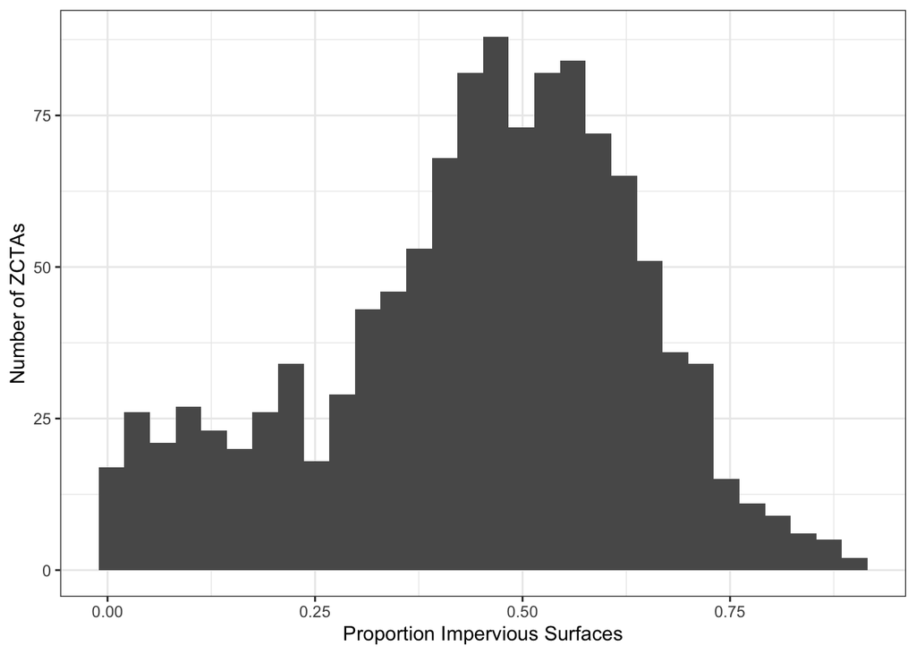

### 1.2.2 Tree canopy

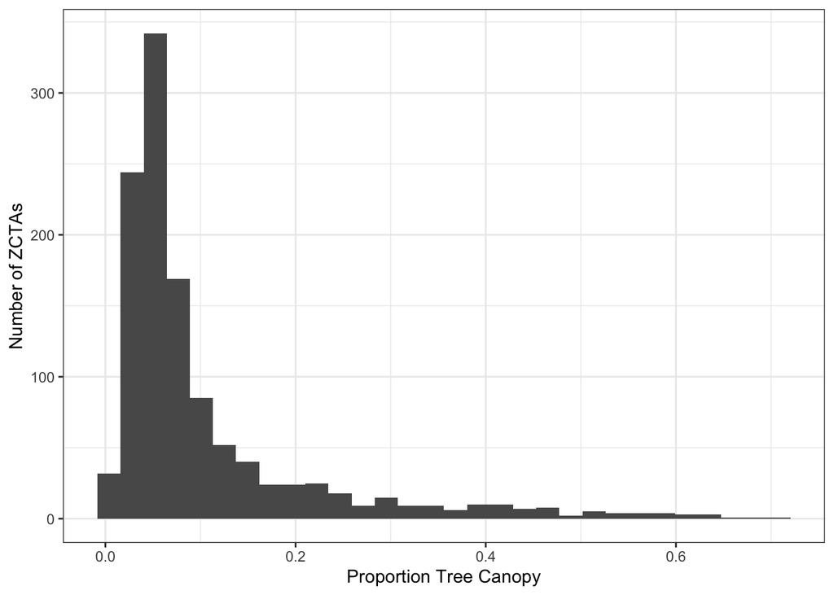

## 1.3 Covariates

### 1.3.1 Proportion with health insurance

Distribution over ZCTAs

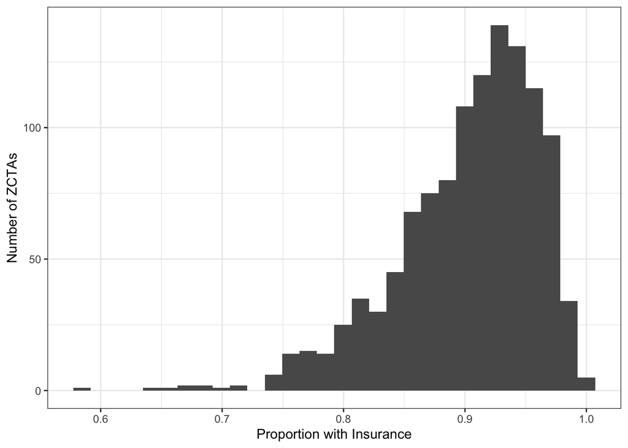

### 1.3.2 Rural-urban classification

Definitions of rural-urban commuting codes:

1. Metropolitan area core: primary flow within an urbanized area (UA)
2. Metropolitan area high commuting: primary flow 30% or more to a UA
3. Metropolitan area low commuting: primary flow 10% to 30% to a UA
4. Micropolitan area core: primary flow within an Urban Cluster of 10,000 to 49,999 (large UC)
5. Micropolitan high commuting: primary flow 30% or more to a large UC
6. Micropolitan low commuting: primary flow 10% to 30% to a large UC
7. Small town core: primary flow within an Urban Cluster of 2,500 to 9,999 (small UC)
8. Small town high commuting: primary flow 30% or more to a small UC
9. Small town low commuting: primary flow 10% to 30% to a small UC
10. Rural areas: primary flow to a tract outside a UA or UC

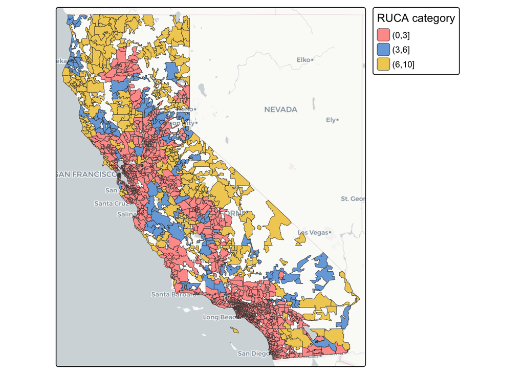

### 1.3.3 Biome

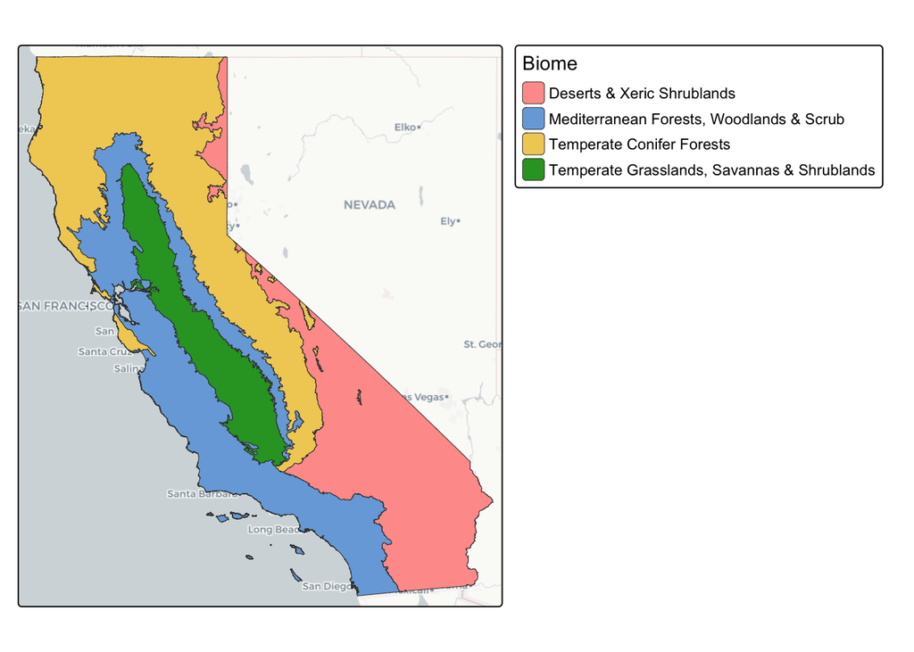

# 2 Bivariate Associations

In scatterplots, points are ZCTAs.

## 2.1 Between RDs and intervention measures

Heat RD vs impervious surfaces

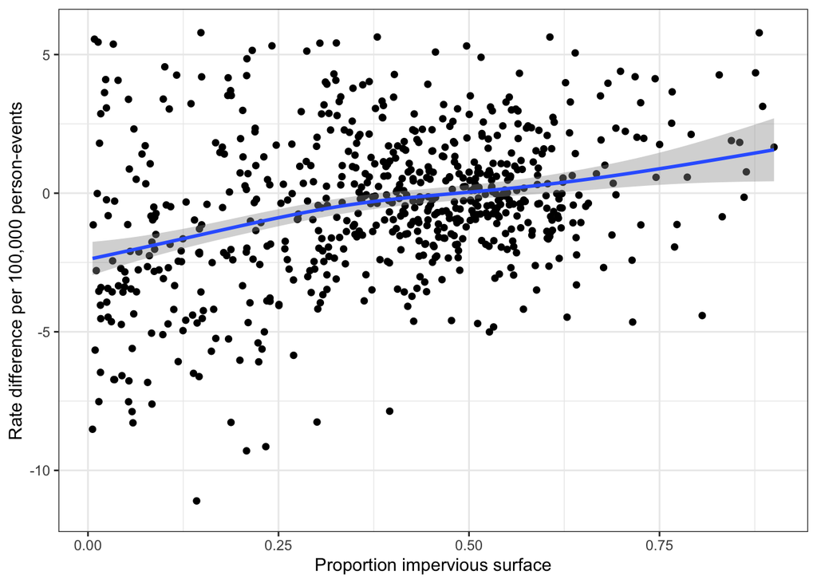

Heat RD vs tree canopy

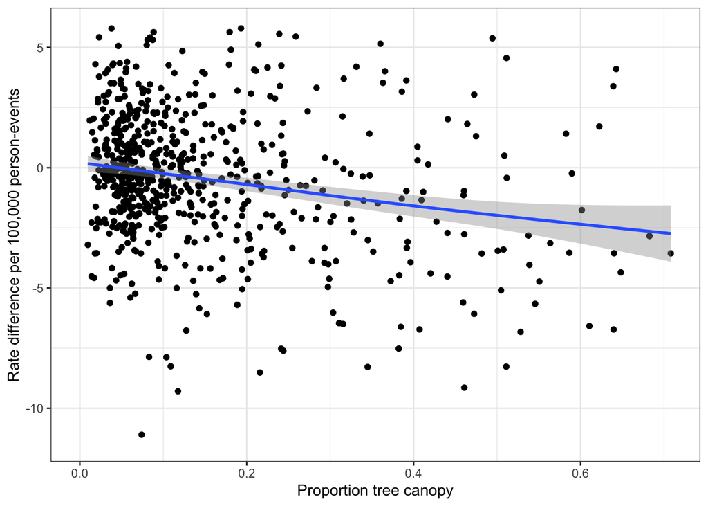

Wildfire RD vs impervious surfaces

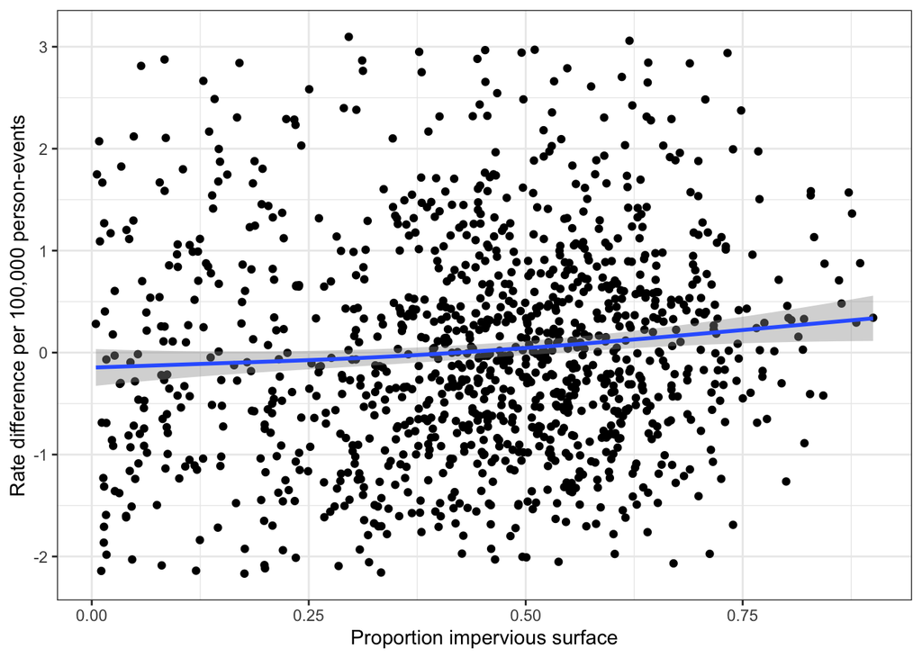

Wildfire RD vs tree canopy

[figure not shown]

## 2.2 Between RDs and other covariates

Heat RD vs proportion insured

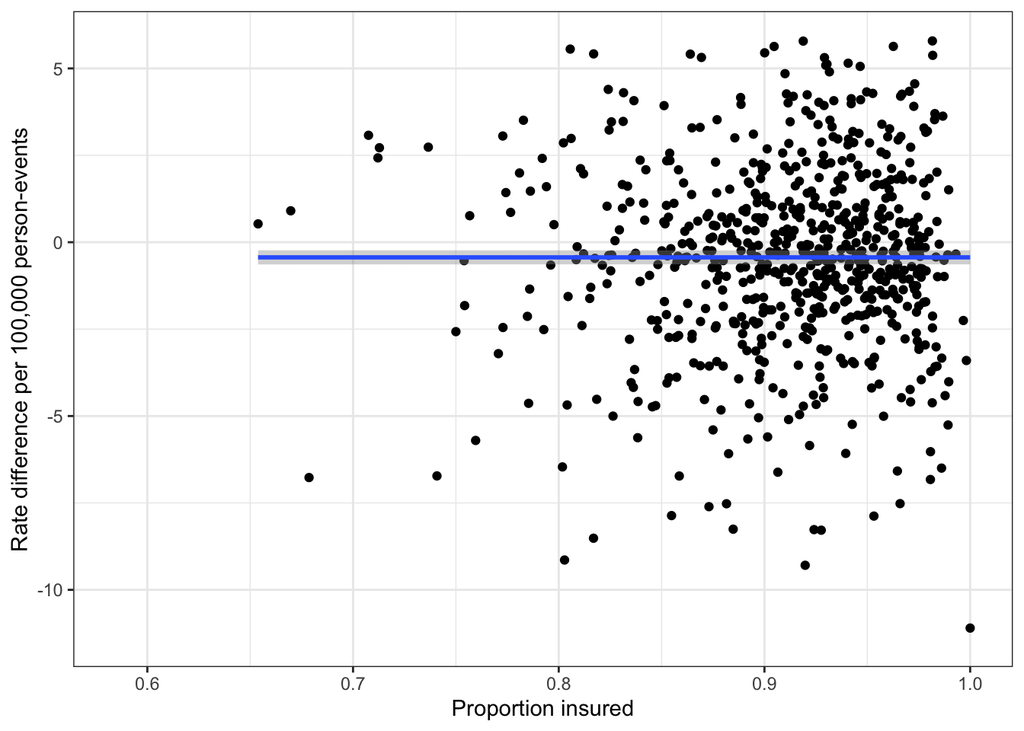

Heat RD vs rural-urban category

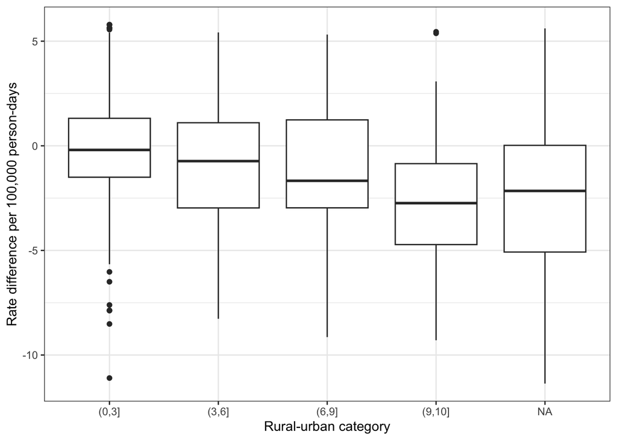

Heat RD vs biome

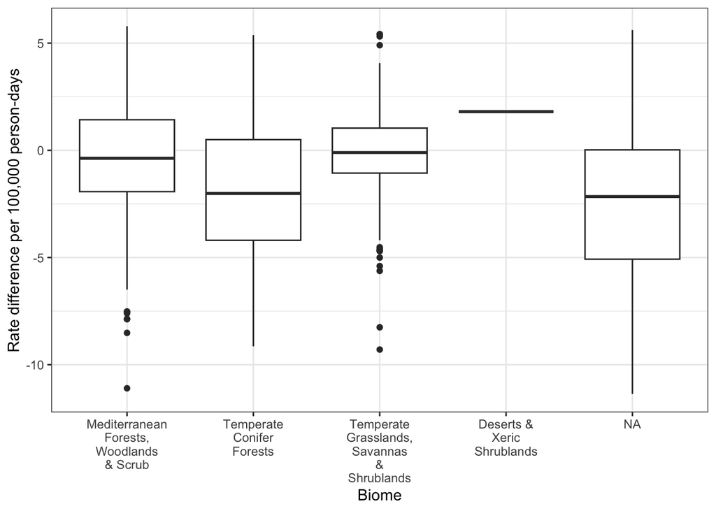

Wildfire RD vs proportion insured

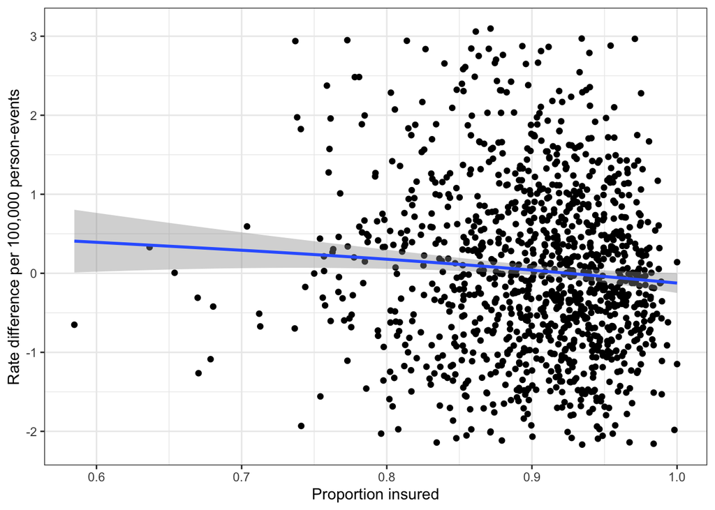

Wildfire RD vs rural-urban category

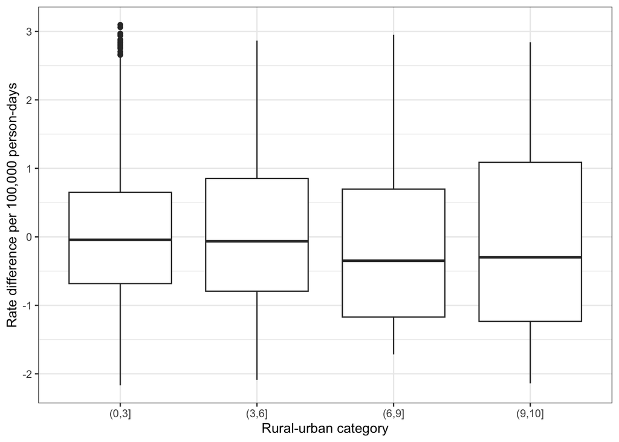

Wildfire RD vs biome

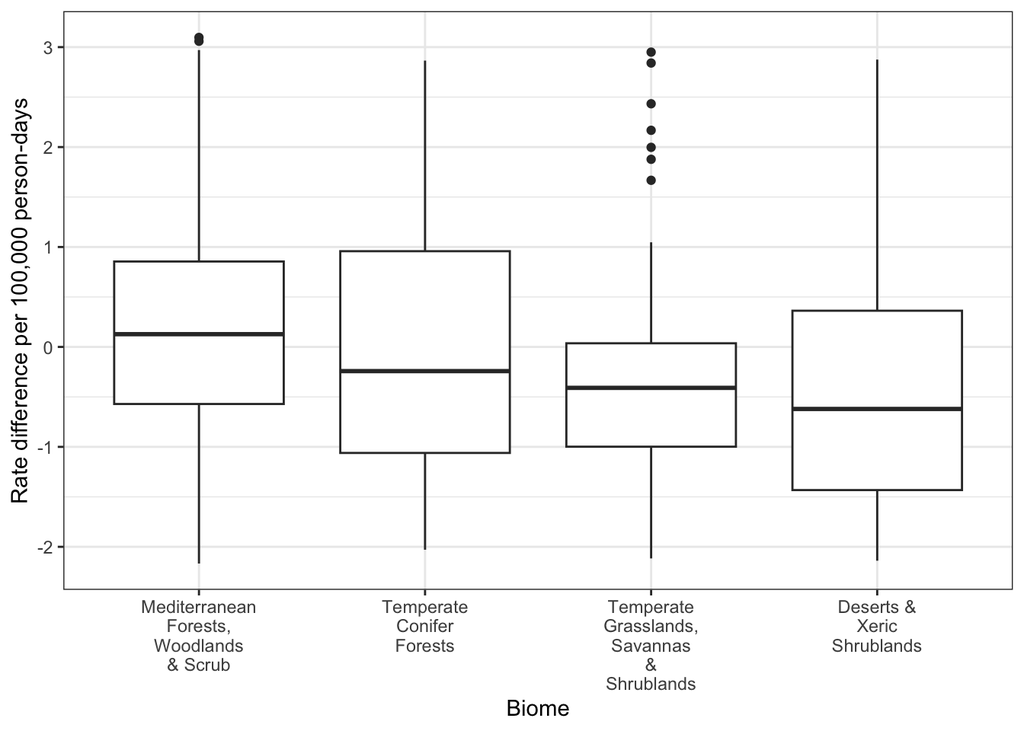

## 2.3 Between Intervention measures and other covariates

Impervious surfaces vs Proportion insured

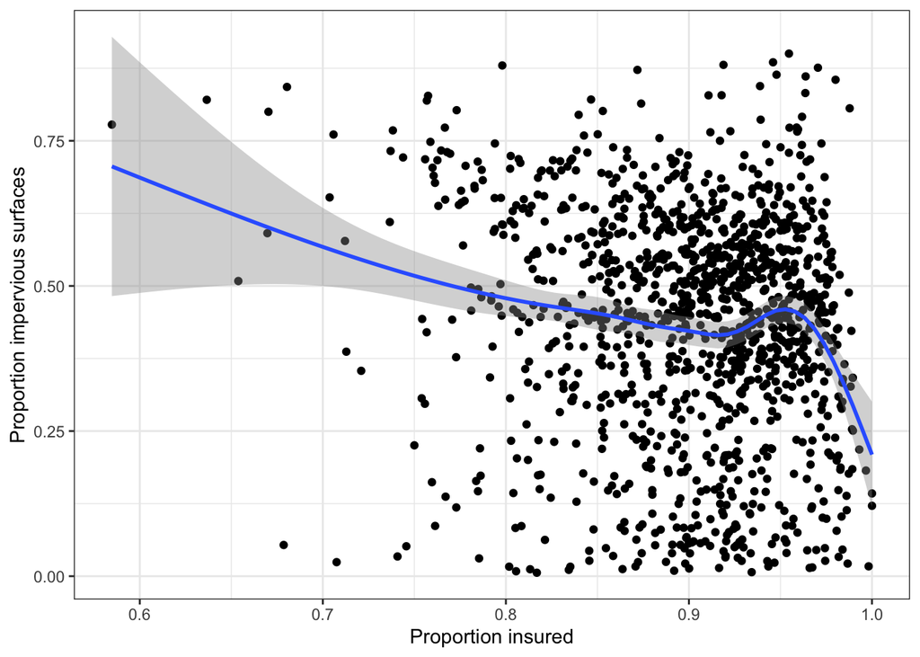

Impervious surfaces vs RUCA

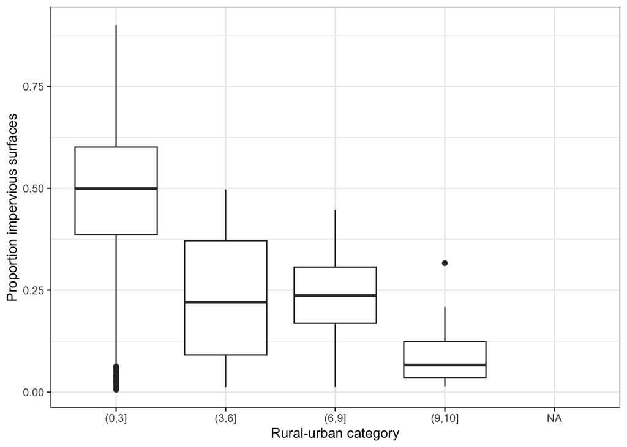

Impervious surfaces vs biome

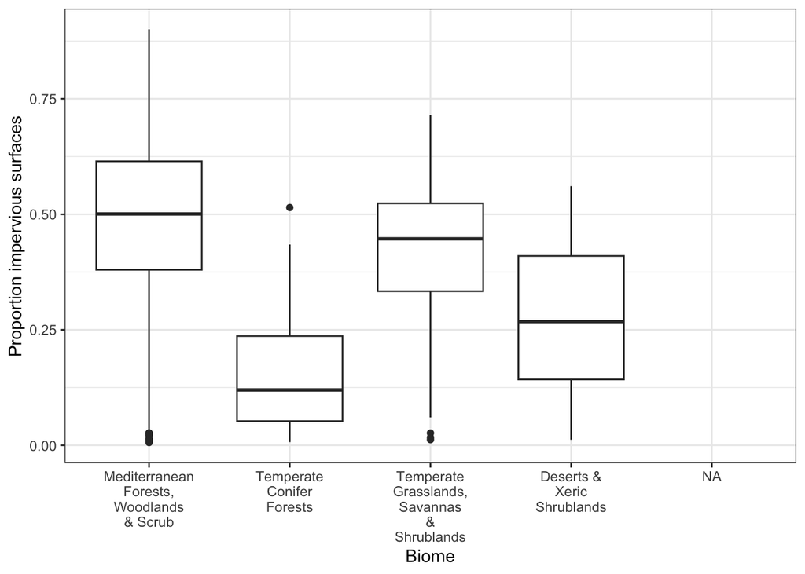

Tree canopy vs Proportion insured

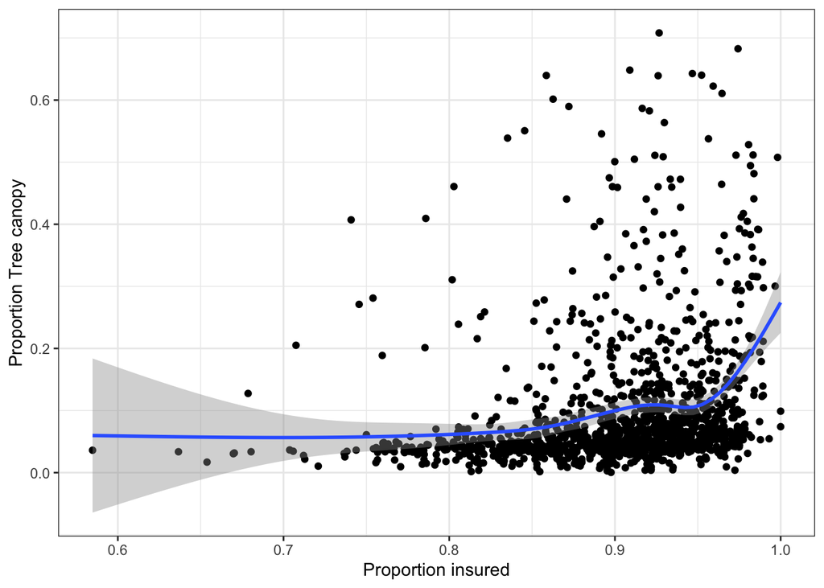

Tree canopy vs RUCA

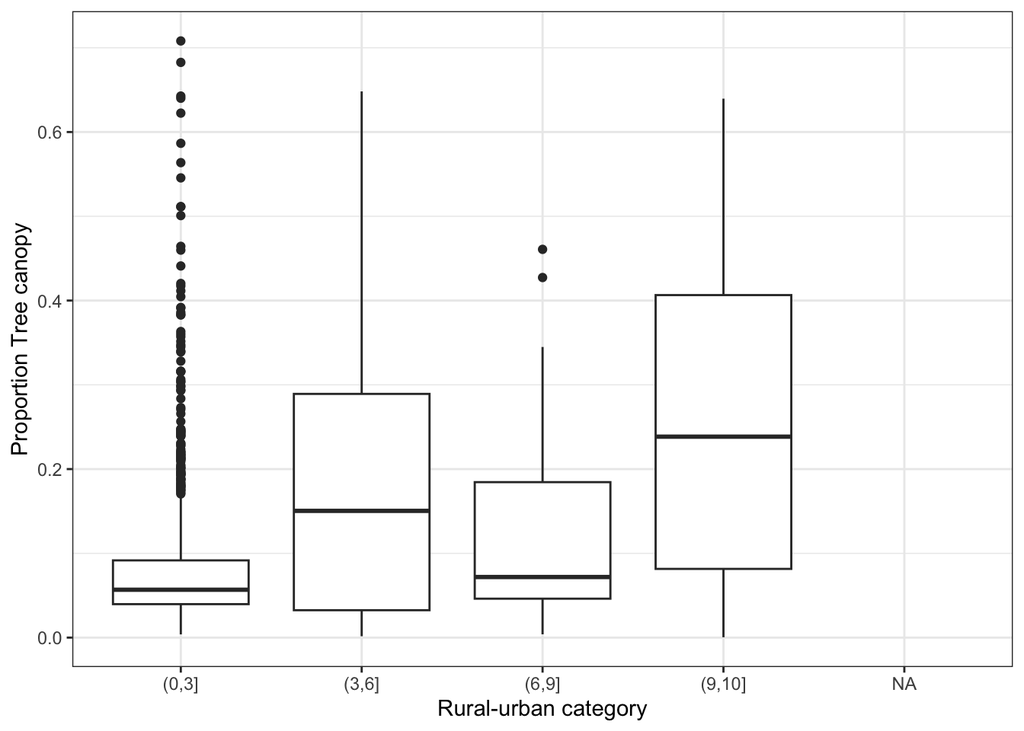

Tree canopy vs biome

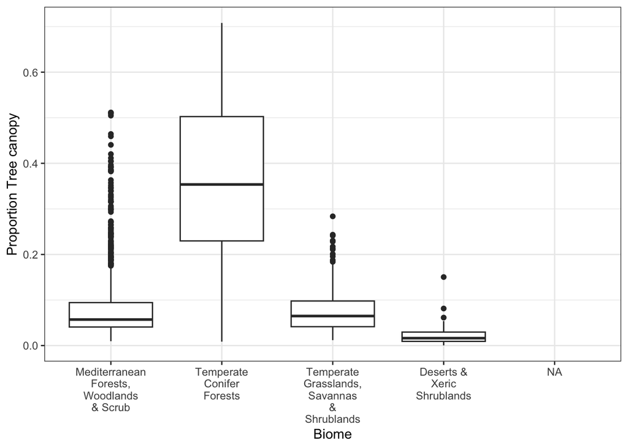